# AI_CA5_P2

[figure not shown]

In the name of God  
University of Tehran  
Artificial Intelligence  
Spring 1401

CA5 Phase 2 Neural Network

Ali Eftekhari  
SID : 810198549

```python
from google.colab import drive
drive.mount('/content/drive')
```

# Phase 1

```python
import numpy as np
import pandas as pd
from matplotlib import pyplot as plt
import seaborn as sns
import tensorflow
from tensorflow import keras
import tensorboard
import os
from sklearn.model_selection import train_test_split
from sklearn.preprocessing import OneHotEncoder
import matplotlib.image as mpimg
from PIL import Image
from keras.layers import LeakyReLU
from sklearn.metrics import classification_report
```

```python
df = pd.read_csv('/content/drive/MyDrive/Colab Notebooks/A_Z Handwritten Data.csv')
```

```python
X = df.drop('0',axis=1)
y = pd.DataFrame(df['0'])

x_train, x_test, y_train, y_test = train_test_split(X, y, test_size = 0.2)
x_train = np.reshape(x_train.values , (x_train.shape[0], 28, 28))
x_test = np.reshape(x_test.values, (x_test.shape[0], 28, 28))
print('new shape of x train: ',x_train.shape)
print(' new shape of x test shape: ', x_test.shape)
print('new shape for y train : ', y_train.shape)
print('new shape for y test: ', y_test.shape)
# x_train  = x_train.reshape(x_train.shape[0], x_train.shape[1], x_train.shape[2], 1)
# x_test  = x_test.reshape(x_test.shape[0], x_test.shape[1], x_test.shape[2], 1)
# print('new shape of x train: ',x_train.shape)
# print(' new shape of x test shape: ', x_test.shape)
# print('new shape for y train : ', y_train.shape)
# print('new shape for y test: ', y_test.shape)
```

```
new shape of x train:  (297960, 28, 28)
 new shape of x test shape:  (74490, 28, 28)
new shape for y train :  (297960, 1)
new shape for y test:  (74490, 1)
```

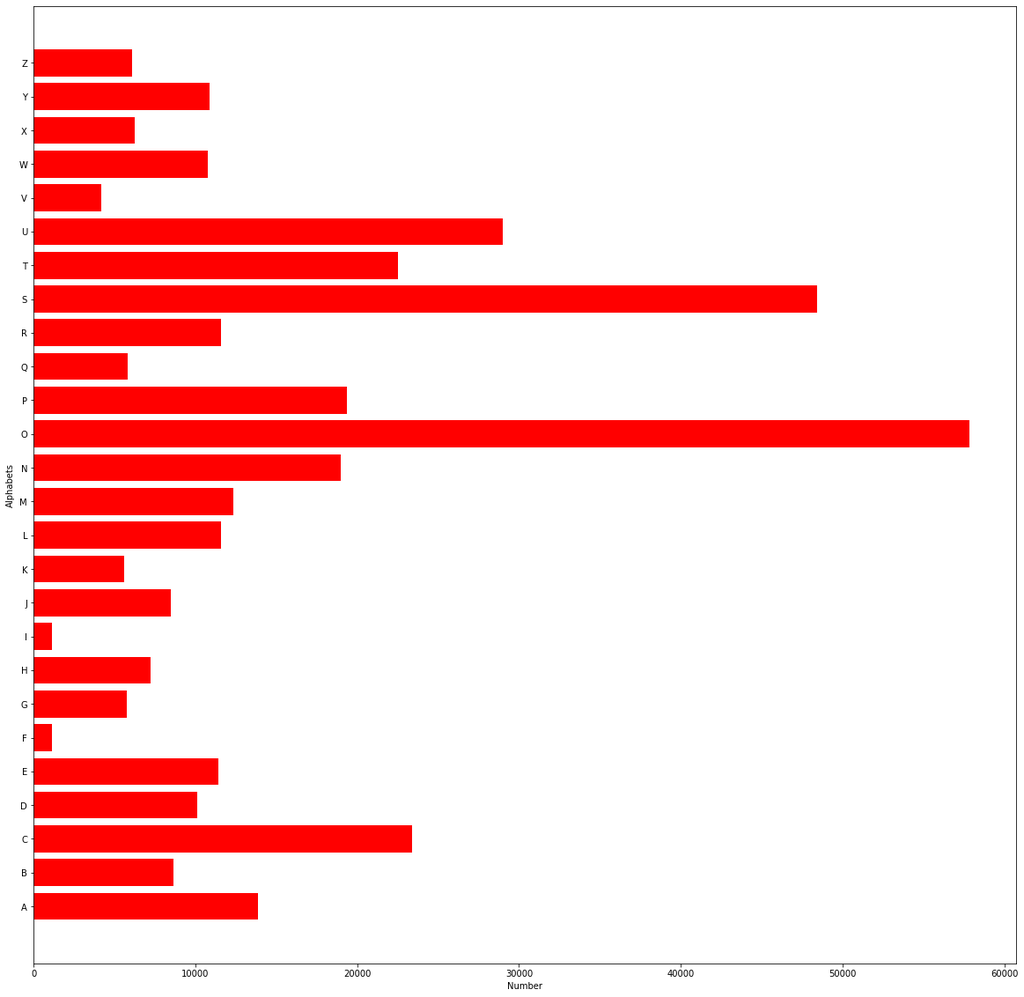

```python
encoded = {0:'A',1:'B',2:'C',3:'D',4:'E',5:'F',6:'G',7:'H',8:'I',9:'J',10:'K',11:'L',12:'M',13:'N'
          ,14:'O',15:'P',16:'Q',17:'R',18:'S',19:'T',20:'U',21:'V',22:'W',23:'X', 24:'Y',25:'Z'}
y_int = np.int0(y)
count = np.zeros(26, dtype='int')
for i in y_int:
    count[i] +=1

alphabets = []
for i in encoded.values():
    alphabets.append(i)

fig, ax = plt.subplots(1,1, figsize=(20,20))
ax.barh(alphabets, count,color = 'r')
plt.xlabel("Number")
plt.ylabel("Alphabets")
plt.show()
```

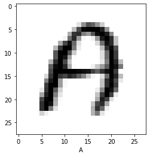

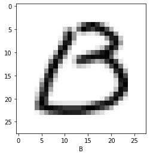

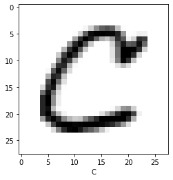

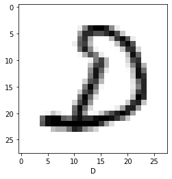

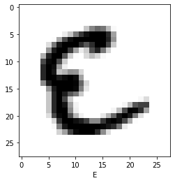

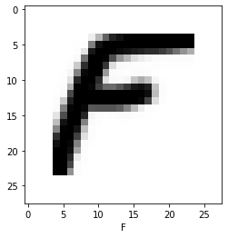

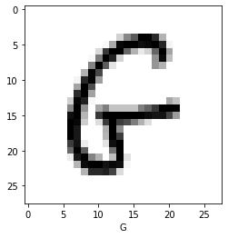

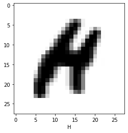

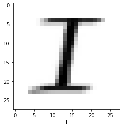

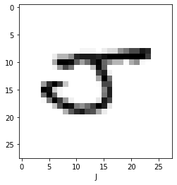

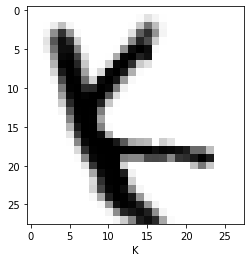

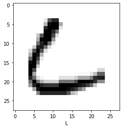

[14 more figures not shown]

```python
for i in range(26):
    dd = df[df['0']==i].iloc[1]
    x = dd[1:].values
    x = x.reshape((28, 28))
    plt.xlabel(encoded[i])
    plt.imshow(x, cmap='binary')
    plt.show()
```

```python
type(y)
y.head(5)
```

|  | 0 |
| --- | --- |
| 0 | 0 |
| 1 | 0 |
| 2 | 0 |
| 3 | 0 |
| 4 | 0 |

#### Machine learning and deep learning models require all of their input and output variables to be numeric in Keras,so we have to encode lables.Another thing to mention is that the last layer of neural network should have neurons with the number of classes that we have to classify them.Actually , every neuron gives the probabilty of input to be the member of that specific class.

```python
ohe = OneHotEncoder()
y_train = keras.utils.to_categorical(y_train, num_classes = 26, dtype='int')
y_test = keras.utils.to_categorical(y_test, num_classes = 26, dtype='int')
print('new shape for y train : ', y_train.shape)
print('new shape for y test: ', y_test.shape)
```

```
new shape for y train :  (297960, 26)
new shape for y test:  (74490, 26)
```

# Phase 2

```python
input = keras.layers.Input(shape=(28,28,1))
output = keras.layers.Flatten()(input)
output = keras.layers.Dense(1024, activation='relu')(output)
output = keras.layers.Dense(512, activation='relu')(output)
output = keras.layers.Dense(26, activation='softmax')(output)
```

```python
model = keras.models.Model(inputs=input, outputs=output)
```

```python
from keras import backend as K

def recall_m(y_true, y_pred):
    true_positives = K.sum(K.round(K.clip(y_true * y_pred, 0, 1)))
    possible_positives = K.sum(K.round(K.clip(y_true, 0, 1)))
    recall = true_positives / (possible_positives + K.epsilon())
    return recall

def precision_m(y_true, y_pred):
    true_positives = K.sum(K.round(K.clip(y_true * y_pred, 0, 1)))
    predicted_positives = K.sum(K.round(K.clip(y_pred, 0, 1)))
    precision = true_positives / (predicted_positives + K.epsilon())
    return precision

def f1_m(y_true, y_pred):
    precision = precision_m(y_true, y_pred)
    recall = recall_m(y_true, y_pred)
    return 2*((precision*recall)/(precision+recall+K.epsilon()))
```

```python
model.compile(optimizer=keras.optimizers.SGD(learning_rate=0.01), loss="binary_crossentropy",metrics=['accuracy'])
```

```python
model.summary()
```

```
Model: "model"
_________________________________________________________________
 Layer (type)                Output Shape              Param #
=================================================================
 input_1 (InputLayer)        [(None, 28, 28, 1)]       0

 flatten (Flatten)           (None, 784)               0

 dense (Dense)               (None, 1024)              803840

 dense_1 (Dense)             (None, 512)               524800

 dense_2 (Dense)             (None, 26)                13338

=================================================================
Total params: 1,341,978
Trainable params: 1,341,978
Non-trainable params: 0
_________________________________________________________________
```

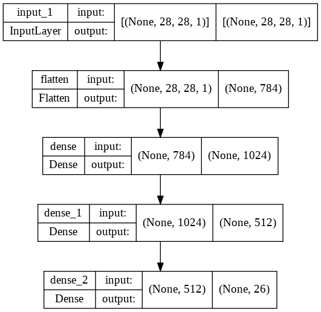

```python
keras.utils.plot_model(model, show_shapes=True, expand_nested=True)
```

```python
log = model.fit(x_train,y_train,batch_size=32, epochs=10,validation_data=(x_test,y_test))
```

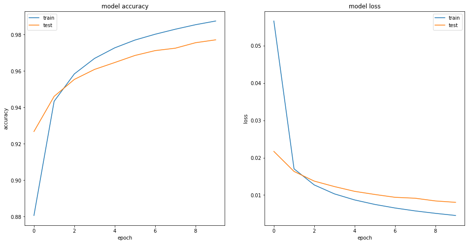

```python
plt.figure(figsize=(16,8))
plt.subplot(1,2,1)
plt.plot(log.history['accuracy'])
plt.plot(log.history['val_accuracy'])
plt.title('model accuracy')
plt.ylabel('accuracy')
plt.xlabel('epoch')
plt.legend(['train', 'test'])
plt.subplot(1,2,2)
plt.plot(log.history['loss'])
plt.plot(log.history['val_loss'])
plt.title('model loss')
plt.ylabel('loss')
plt.xlabel('epoch')
plt.legend(['train', 'test'])
plt.show()
```

```python
selected = np.random.randint(x_test.shape[0], size=100)
loss, accuracy, f1_score, precision, recall = model.evaluate(x_test, y_test, verbose=0)
print('Test Score:',f1_score)
print('Test Accuracy:',accuracy*100)
print('Test Precision:',precision)
print('Test Loss:',loss)
print('Test Recall:',recall)
```

[output not shown]

```python
y_pred = model.predict(x_test, batch_size=32, verbose=1)
y_pred_bool = np.argmax(np.array(y_pred), axis=1)

print(classification_report(y_pred_bool,np.argmax(np.array(y_test), axis=1)))
```

```
              precision    recall  f1-score   support

           0       0.98      0.95      0.96      2851
           1       0.97      0.95      0.96      1747
           2       0.99      0.98      0.98      4679
           3       0.95      0.93      0.94      2046
           4       0.97      0.96      0.97      2276
           5       0.93      0.94      0.94       230
           6       0.92      0.96      0.94      1111
           7       0.94      0.94      0.94      1415
           8       0.88      0.98      0.93       194
           9       0.96      0.97      0.97      1696
          10       0.94      0.96      0.95      1114
          11       0.98      0.99      0.98      2277
          12       0.96      0.98      0.97      2480
```

[output cut: 17 more lines]

# Phase 3

#### Now we normalize the data between 0 and 1.

```python
data = np.array(df) # convert into numpy array
X = data.T[1:].T
Y = data.T[0]
X_train, X_test, Y_train, Y_test = train_test_split(X, Y, test_size=0.15)
```

```python
X_train = np.reshape(X_train.astype('float32')/255.0, (X_train.shape[0], 28, 28))
X_test = np.reshape(X_test.astype('float32')/255.0, (X_test.shape[0], 28, 28))
ohe = OneHotEncoder()
Y_train = keras.utils.to_categorical(Y_train, num_classes = 26, dtype='int')
Y_test = keras.utils.to_categorical(Y_test, num_classes = 26, dtype='int')
print('new shape for y train : ', Y_train.shape)
print('new shape for y test: ', Y_test.shape)
```

```
new shape for y train :  (316582, 26)
new shape for y test:  (55868, 26)
```

### Create new input and output for keras and using Tanh

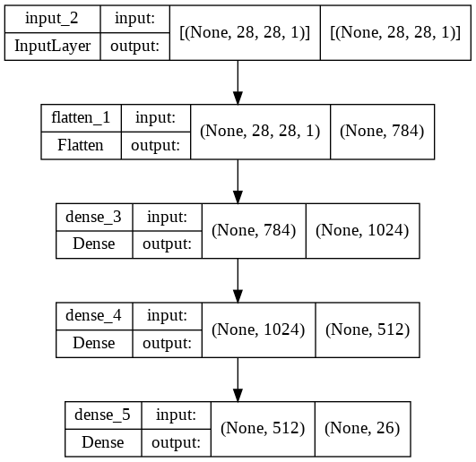

```python
input = keras.layers.Input(shape=(28,28,1))
output = keras.layers.Flatten()(input)
output = keras.layers.Dense(1024, activation='tanh')(output)
output = keras.layers.Dense(512, activation='tanh')(output)
output = keras.layers.Dense(26, activation='softmax')(output)
model = keras.models.Model(inputs=input, outputs=output)
model.compile(optimizer=keras.optimizers.SGD(learning_rate=0.01), loss="binary_crossentropy",metrics=['accuracy'])
keras.utils.plot_model(model, show_shapes=True, expand_nested=True)
```

```python
log = model.fit(X_train,Y_train,batch_size=32, epochs=10,validation_data=(X_test,Y_test))
```

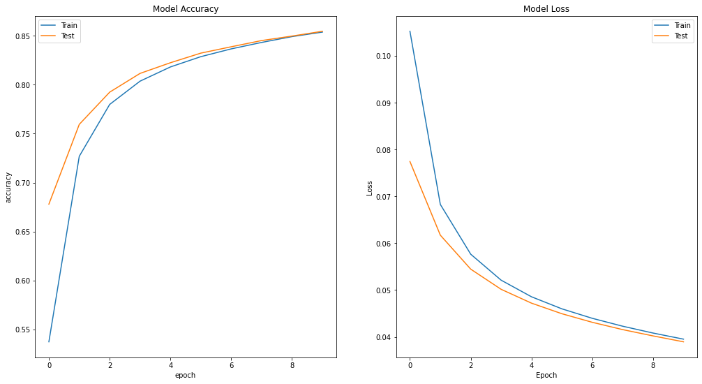

```python
plt.figure(figsize=(17,9))
plt.subplot(1,2,1)
plt.plot(log.history['accuracy'])
plt.plot(log.history['val_accuracy'])
plt.title('Model Accuracy')
plt.ylabel('accuracy')
plt.xlabel('epoch')
plt.legend(['Train', 'Test'])
plt.subplot(1,2,2)
plt.plot(log.history['loss'])
plt.plot(log.history['val_loss'])
plt.title('Model Loss')
plt.ylabel('Loss')
plt.xlabel('Epoch')
plt.legend(['Train', 'Test'])
plt.show()
```

```python
Y_pred = model.predict(X_test, batch_size=32, verbose=1)
Y_pred_bool = np.argmax(np.array(Y_pred), axis=1)

print(classification_report(Y_pred_bool,np.argmax(np.array(Y_test), axis=1)))
```

```
              precision    recall  f1-score   support

           0       0.84      0.78      0.81      2277
           1       0.71      0.81      0.76      1161
           2       0.90      0.89      0.89      3563
           3       0.71      0.79      0.75      1388
           4       0.77      0.80      0.79      1621
           5       0.42      0.94      0.58        77
           6       0.65      0.85      0.74       682
           7       0.58      0.76      0.66       824
           8       0.44      0.95      0.60        88
           9       0.61      0.79      0.69       989
          10       0.67      0.72      0.70       809
          11       0.94      0.88      0.91      1772
          12       0.90      0.83      0.86      1932
```

[output cut: 17 more lines]

### Leaky Relu

```python
model = keras.Sequential()
model.add(keras.layers.Input(shape=(28,28,1)))
model.add(keras.layers.Flatten())
model.add(keras.layers.Dense(1024))
model.add(keras.layers.LeakyReLU(alpha=0.05))
model.add(keras.layers.Dense(512))
model.add(keras.layers.LeakyReLU(alpha=0.05))
model.add(keras.layers.Dense(26, activation='softmax'))
model.compile(optimizer=keras.optimizers.SGD(learning_rate=0.01), loss="binary_crossentropy",metrics=['accuracy'])
model.summary()
```

```
Model: "sequential"
_________________________________________________________________
 Layer (type)                Output Shape              Param #
=================================================================
 flatten_2 (Flatten)         (None, 784)               0

 dense_6 (Dense)             (None, 1024)              803840

 leaky_re_lu (LeakyReLU)     (None, 1024)              0

 dense_7 (Dense)             (None, 512)               524800

 leaky_re_lu_1 (LeakyReLU)   (None, 512)               0

 dense_8 (Dense)             (None, 26)                13338

=================================================================
Total params: 1,341,978
Trainable params: 1,341,978
Non-trainable params: 0
_________________________________________________________________
```

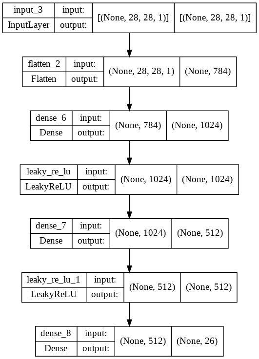

```python
keras.utils.plot_model(model, show_shapes=True, expand_nested=True)
```

```python
log = model.fit(X_train,Y_train,batch_size=32, epochs=10,validation_data=(X_test,Y_test))
```

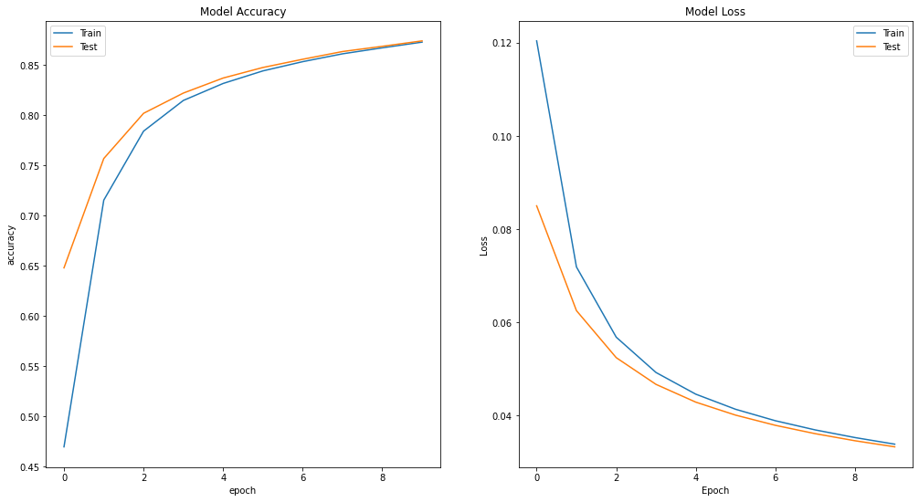

```python
plt.figure(figsize=(17,9))
plt.subplot(1,2,1)
plt.plot(log.history['accuracy'])
plt.plot(log.history['val_accuracy'])
plt.title('Model Accuracy')
plt.ylabel('accuracy')
plt.xlabel('epoch')
plt.legend(['Train', 'Test'])
plt.subplot(1,2,2)
plt.plot(log.history['loss'])
plt.plot(log.history['val_loss'])
plt.title('Model Loss')
plt.ylabel('Loss')
plt.xlabel('Epoch')
plt.legend(['Train', 'Test'])
plt.show()
```

```python
Y_pred = model.predict(X_test, batch_size=32, verbose=1)
Y_pred_bool = np.argmax(np.array(Y_pred), axis=1)

print(classification_report(Y_pred_bool,np.argmax(np.array(Y_test), axis=1)))
```

```
              precision    recall  f1-score   support

           0       0.86      0.82      0.84      2224
           1       0.74      0.83      0.79      1177
           2       0.90      0.92      0.91      3470
           3       0.75      0.82      0.78      1396
           4       0.81      0.83      0.82      1642
           5       0.55      0.95      0.70       100
           6       0.72      0.86      0.78       740
           7       0.63      0.79      0.70       861
           8       0.55      0.95      0.70       110
           9       0.67      0.83      0.74      1046
          10       0.69      0.75      0.72       809
          11       0.95      0.88      0.91      1788
          12       0.91      0.82      0.86      1959
```

[output cut: 17 more lines]

## Sigmoid

```
Model: "model_2"
_________________________________________________________________
 Layer (type)                Output Shape              Param #
=================================================================
 input_4 (InputLayer)        [(None, 28, 28, 1)]       0

 flatten_3 (Flatten)         (None, 784)               0

 dense_9 (Dense)             (None, 1024)              803840

 dense_10 (Dense)            (None, 512)               524800

 dense_11 (Dense)            (None, 26)                13338

=================================================================
Total params: 1,341,978
Trainable params: 1,341,978
Non-trainable params: 0
_________________________________________________________________
```

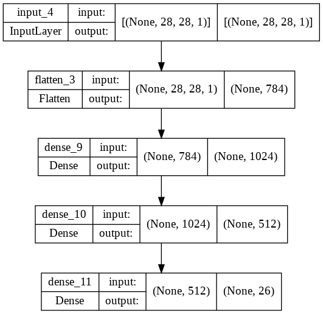

```python
input = keras.layers.Input(shape=(28,28,1))
output = keras.layers.Flatten()(input)
output = keras.layers.Dense(1024, activation='sigmoid')(output)
output = keras.layers.Dense(512, activation='sigmoid')(output)
output = keras.layers.Dense(26, activation='softmax')(output)
model = keras.models.Model(inputs=input, outputs=output)
model.compile(optimizer=keras.optimizers.SGD(learning_rate=0.01), loss="binary_crossentropy",metrics=['accuracy'])
model.summary()
keras.utils.plot_model(model, show_shapes=True, expand_nested=True)
```

```python
log = model.fit(X_train,Y_train,batch_size=32, epochs=10,validation_data=(X_test,Y_test))
```

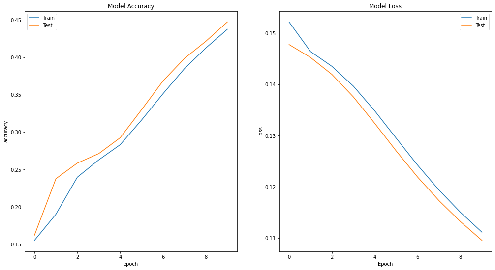

```python
plt.figure(figsize=(17,9))
plt.subplot(1,2,1)
plt.plot(log.history['accuracy'])
plt.plot(log.history['val_accuracy'])
plt.title('Model Accuracy')
plt.ylabel('accuracy')
plt.xlabel('epoch')
plt.legend(['Train', 'Test'])
plt.subplot(1,2,2)
plt.plot(log.history['loss'])
plt.plot(log.history['val_loss'])
plt.title('Model Loss')
plt.ylabel('Loss')
plt.xlabel('Epoch')
plt.legend(['Train', 'Test'])
plt.show()
```

```python
Y_pred = model.predict(X_test, batch_size=32, verbose=1)
Y_pred_bool = np.argmax(np.array(Y_pred), axis=1)

print(classification_report(Y_pred_bool,np.argmax(np.array(Y_test), axis=1)))
```

```
              precision    recall  f1-score   support

           0       0.14      0.72      0.23       404
           1       0.00      0.00      0.00         0
           2       0.33      0.56      0.42      2090
           3       0.00      0.00      0.00         0
           4       0.00      0.00      0.00         0
           5       0.00      0.00      0.00         0
           6       0.00      0.00      0.00         0
           7       0.00      0.00      0.00         0
           8       0.00      0.00      0.00         0
           9       0.00      0.00      0.00         0
          10       0.00      0.00      0.00         0
          11       0.00      1.00      0.00         1
          12       0.12      1.00      0.21       209
```

[output cut: 17 more lines]

# Optimizers:

## Momentum:

### Momentum is a strategy to accelerate the convergence of gradient-based optimization techniques.It is a variant of the stochastic gradient descent.momentum is known to speed up learning and to help not getting stuck in local minima.Stochastic gradient descent picks a random instance from the dataset at every step and calculates the gradient only on a single instance.Due to its stochastic (random) nature, this algorithm converges less regularly than batch gradient descent; it keeps oscillating toward convergence. Momentum is used to remove its random convergence.

### momentum 0.5

```python
model = keras.Sequential()
model.add(keras.layers.Input(shape=(28,28,1)))
model.add(keras.layers.Flatten())
model.add(keras.layers.Dense(1024))
model.add(keras.layers.LeakyReLU(alpha=0.05))
model.add(keras.layers.Dense(512))
model.add(keras.layers.LeakyReLU(alpha=0.05))
model.add(keras.layers.Dense(26, activation='softmax'))
model.compile(optimizer=keras.optimizers.SGD(learning_rate=0.01,momentum=0.5), loss="binary_crossentropy",metrics=['accuracy'])
model.summary()
```

```
Model: "sequential_6"
_________________________________________________________________
 Layer (type)                Output Shape              Param #
=================================================================
 flatten_9 (Flatten)         (None, 784)               0

 dense_27 (Dense)            (None, 1024)              803840

 leaky_re_lu_12 (LeakyReLU)  (None, 1024)              0

 dense_28 (Dense)            (None, 512)               524800

 leaky_re_lu_13 (LeakyReLU)  (None, 512)               0

 dense_29 (Dense)            (None, 26)                13338

=================================================================
Total params: 1,341,978
Trainable params: 1,341,978
Non-trainable params: 0
_________________________________________________________________
```

```python
log = model.fit(X_train,Y_train,batch_size=32, epochs=10,validation_data=(X_test,Y_test))
```

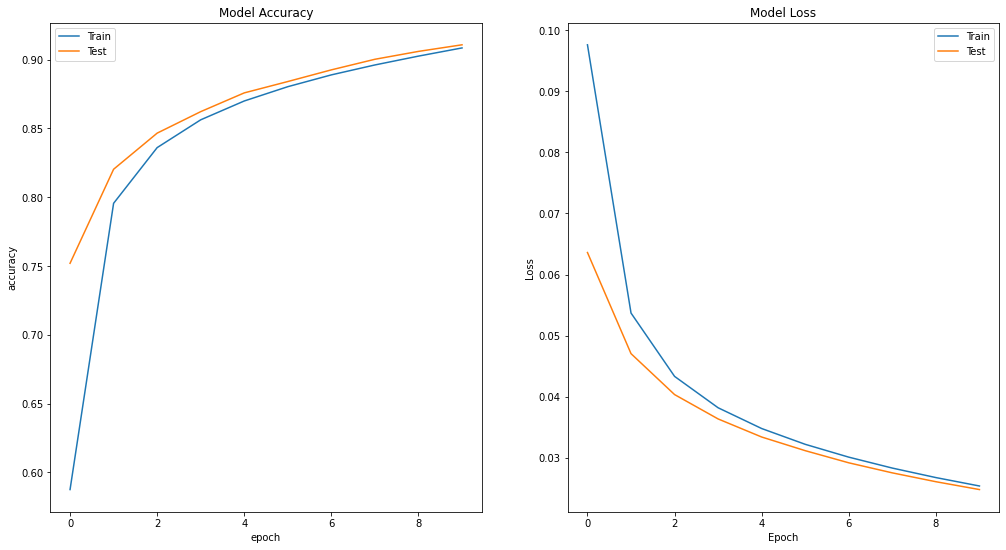

```python
plt.figure(figsize=(17,9))
plt.subplot(1,2,1)
plt.plot(log.history['accuracy'])
plt.plot(log.history['val_accuracy'])
plt.title('Model Accuracy')
plt.ylabel('accuracy')
plt.xlabel('epoch')
plt.legend(['Train', 'Test'])
plt.subplot(1,2,2)
plt.plot(log.history['loss'])
plt.plot(log.history['val_loss'])
plt.title('Model Loss')
plt.ylabel('Loss')
plt.xlabel('Epoch')
plt.legend(['Train', 'Test'])
plt.show()
```

```python
Y_pred = model.predict(X_test, batch_size=32, verbose=1)
Y_pred_bool = np.argmax(np.array(Y_pred), axis=1)

print(classification_report(Y_pred_bool,np.argmax(np.array(Y_test), axis=1)))
```

```
              precision    recall  f1-score   support

           0       0.90      0.86      0.88      2225
           1       0.81      0.87      0.84      1236
           2       0.94      0.93      0.93      3542
           3       0.81      0.88      0.84      1412
           4       0.84      0.88      0.86      1598
           5       0.73      0.95      0.83       133
           6       0.77      0.90      0.83       764
           7       0.74      0.83      0.78       962
           8       0.70      0.93      0.80       143
           9       0.81      0.89      0.84      1169
          10       0.78      0.77      0.77       880
          11       0.96      0.90      0.93      1766
          12       0.92      0.88      0.90      1866
```

[output cut: 17 more lines]

### Momentum 0.9

```python
model = keras.Sequential()
model.add(keras.layers.Input(shape=(28,28,1)))
model.add(keras.layers.Flatten())
model.add(keras.layers.Dense(1024))
model.add(keras.layers.LeakyReLU(alpha=0.05))
model.add(keras.layers.Dense(512))
model.add(keras.layers.LeakyReLU(alpha=0.05))
model.add(keras.layers.Dense(26, activation='softmax'))
model.compile(optimizer=keras.optimizers.SGD(learning_rate=0.01,momentum=0.9), loss="binary_crossentropy",metrics=['accuracy'])
model.summary()
```

```
Model: "sequential_7"
_________________________________________________________________
 Layer (type)                Output Shape              Param #
=================================================================
 flatten_10 (Flatten)        (None, 784)               0

 dense_30 (Dense)            (None, 1024)              803840

 leaky_re_lu_14 (LeakyReLU)  (None, 1024)              0

 dense_31 (Dense)            (None, 512)               524800

 leaky_re_lu_15 (LeakyReLU)  (None, 512)               0

 dense_32 (Dense)            (None, 26)                13338

=================================================================
Total params: 1,341,978
Trainable params: 1,341,978
Non-trainable params: 0
_________________________________________________________________
```

```python
log = model.fit(X_train,Y_train,batch_size=32, epochs=10,validation_data=(X_test,Y_test))
```

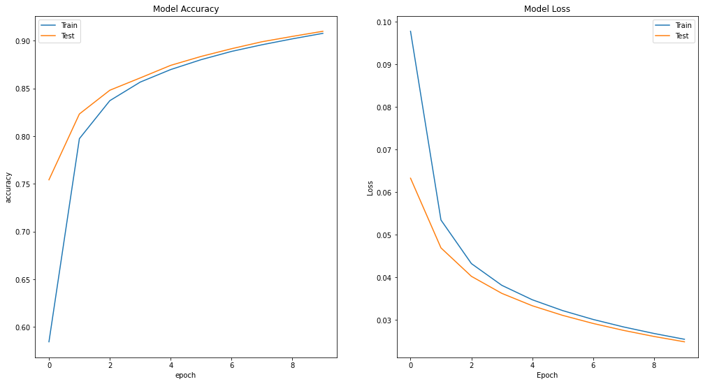

```python
plt.figure(figsize=(17,9))
plt.subplot(1,2,1)
plt.plot(log.history['accuracy'])
plt.plot(log.history['val_accuracy'])
plt.title('Model Accuracy')
plt.ylabel('accuracy')
plt.xlabel('epoch')
plt.legend(['Train', 'Test'])
plt.subplot(1,2,2)
plt.plot(log.history['loss'])
plt.plot(log.history['val_loss'])
plt.title('Model Loss')
plt.ylabel('Loss')
plt.xlabel('Epoch')
plt.legend(['Train', 'Test'])
plt.show()
```

```python
Y_pred = model.predict(X_test, batch_size=32, verbose=1)
Y_pred_bool = np.argmax(np.array(Y_pred), axis=1)

print(classification_report(Y_pred_bool,np.argmax(np.array(Y_test), axis=1)))
```

```
              precision    recall  f1-score   support

           0       0.90      0.85      0.88      2241
           1       0.79      0.88      0.83      1187
           2       0.93      0.94      0.93      3478
           3       0.82      0.87      0.84      1449
           4       0.85      0.87      0.86      1649
           5       0.71      0.96      0.82       128
           6       0.78      0.89      0.83       772
           7       0.72      0.84      0.77       935
           8       0.69      0.94      0.80       140
           9       0.82      0.88      0.85      1190
          10       0.79      0.78      0.79       881
          11       0.96      0.90      0.93      1779
          12       0.93      0.87      0.90      1910
```

[output cut: 17 more lines]

### Momentum 0.98

```python
model = keras.Sequential()
model.add(keras.layers.Input(shape=(28,28,1)))
model.add(keras.layers.Flatten())
model.add(keras.layers.Dense(1024))
model.add(keras.layers.LeakyReLU(alpha=0.05))
model.add(keras.layers.Dense(512))
model.add(keras.layers.LeakyReLU(alpha=0.05))
model.add(keras.layers.Dense(26, activation='softmax'))
model.compile(optimizer=keras.optimizers.SGD(learning_rate=0.01,momentum=0.98), loss="binary_crossentropy",metrics=['accuracy'])
model.summary()
```

```
Model: "sequential_8"
_________________________________________________________________
 Layer (type)                Output Shape              Param #
=================================================================
 flatten_11 (Flatten)        (None, 784)               0

 dense_33 (Dense)            (None, 1024)              803840

 leaky_re_lu_16 (LeakyReLU)  (None, 1024)              0

 dense_34 (Dense)            (None, 512)               524800

 leaky_re_lu_17 (LeakyReLU)  (None, 512)               0

 dense_35 (Dense)            (None, 26)                13338

=================================================================
Total params: 1,341,978
Trainable params: 1,341,978
Non-trainable params: 0
_________________________________________________________________
```

```python
log = model.fit(X_train,Y_train,batch_size=32, epochs=10,validation_data=(X_test,Y_test))
```

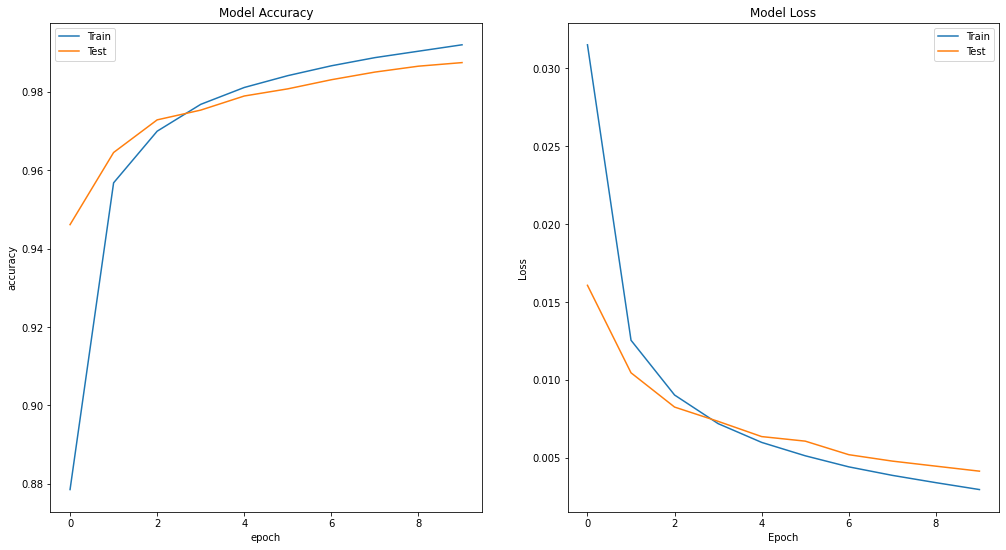

```python
plt.figure(figsize=(17,9))
plt.subplot(1,2,1)
plt.plot(log.history['accuracy'])
plt.plot(log.history['val_accuracy'])
plt.title('Model Accuracy')
plt.ylabel('accuracy')
plt.xlabel('epoch')
plt.legend(['Train', 'Test'])
plt.subplot(1,2,2)
plt.plot(log.history['loss'])
plt.plot(log.history['val_loss'])
plt.title('Model Loss')
plt.ylabel('Loss')
plt.xlabel('Epoch')
plt.legend(['Train', 'Test'])
plt.show()
```

```python
Y_pred = model.predict(X_test, batch_size=32, verbose=1)
Y_pred_bool = np.argmax(np.array(Y_pred), axis=1)

print(classification_report(Y_pred_bool,np.argmax(np.array(Y_test), axis=1)))
```

```
              precision    recall  f1-score   support

           0       0.99      0.98      0.99      2151
           1       0.98      0.98      0.98      1318
           2       0.99      0.99      0.99      3512
           3       0.96      0.98      0.97      1509
           4       0.98      1.00      0.99      1660
           5       0.93      0.96      0.94       168
           6       0.96      0.98      0.97       869
           7       0.96      0.97      0.97      1073
           8       0.96      0.98      0.97       186
           9       0.97      0.98      0.98      1282
          10       0.98      0.97      0.97       884
          11       0.99      0.98      0.98      1689
          12       0.99      0.99      0.99      1778
```

[output cut: 17 more lines]

# Adam

#### Adam is an optimization algorithm that can be used instead of the classical stochastic gradient descent procedure to update network weights iterative based in training data.

```python
model = keras.Sequential()
model.add(keras.layers.Input(shape=(28,28,1)))
model.add(keras.layers.Flatten())
model.add(keras.layers.Dense(1024))
model.add(keras.layers.LeakyReLU(alpha=0.05))
model.add(keras.layers.Dense(512))
model.add(keras.layers.LeakyReLU(alpha=0.05))
model.add(keras.layers.Dense(26, activation='softmax'))
model.compile(optimizer='adam', loss="binary_crossentropy",metrics=['accuracy'])
model.summary()
```

```
Model: "sequential_9"
_________________________________________________________________
 Layer (type)                Output Shape              Param #
=================================================================
 flatten_12 (Flatten)        (None, 784)               0

 dense_36 (Dense)            (None, 1024)              803840

 leaky_re_lu_18 (LeakyReLU)  (None, 1024)              0

 dense_37 (Dense)            (None, 512)               524800

 leaky_re_lu_19 (LeakyReLU)  (None, 512)               0

 dense_38 (Dense)            (None, 26)                13338

=================================================================
Total params: 1,341,978
Trainable params: 1,341,978
Non-trainable params: 0
_________________________________________________________________
```

```python
log = model.fit(X_train,Y_train,batch_size=32, epochs=10,validation_data=(X_test,Y_test))
```

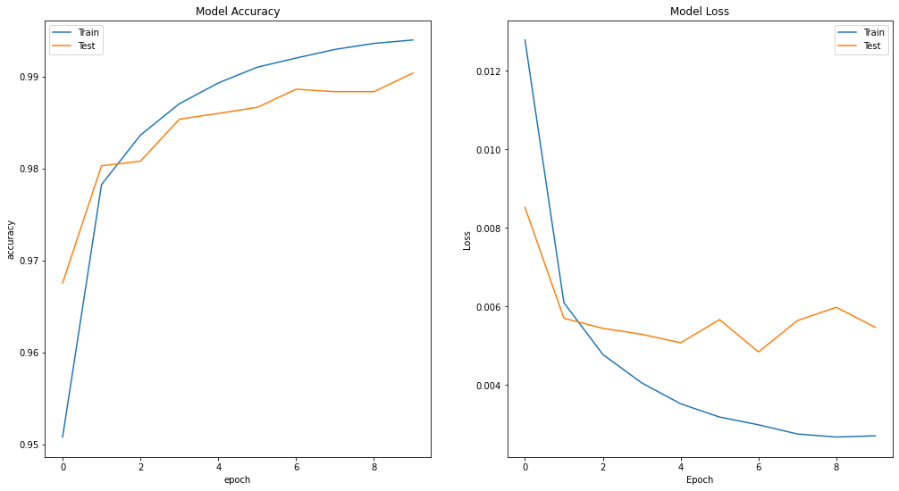

```python
plt.figure(figsize=(17,9))
plt.subplot(1,2,1)
plt.plot(log.history['accuracy'])
plt.plot(log.history['val_accuracy'])
plt.title('Model Accuracy')
plt.ylabel('accuracy')
plt.xlabel('epoch')
plt.legend(['Train', 'Test'])
plt.subplot(1,2,2)
plt.plot(log.history['loss'])
plt.plot(log.history['val_loss'])
plt.title('Model Loss')
plt.ylabel('Loss')
plt.xlabel('Epoch')
plt.legend(['Train', 'Test'])
plt.show()
```

```python
Y_pred = model.predict(X_test, batch_size=32, verbose=1)
Y_pred_bool = np.argmax(np.array(Y_pred), axis=1)

print(classification_report(Y_pred_bool,np.argmax(np.array(Y_test), axis=1)))
```

```
              precision    recall  f1-score   support

           0       0.99      1.00      0.99      2098
           1       0.99      0.99      0.99      1318
           2       0.99      1.00      0.99      3517
           3       0.98      0.95      0.96      1594
           4       0.99      0.99      0.99      1681
           5       0.94      0.99      0.96       164
           6       0.98      0.96      0.97       904
           7       0.98      0.98      0.98      1082
           8       0.99      0.97      0.98       195
           9       0.98      0.99      0.99      1271
          10       0.97      0.98      0.98       859
          11       0.99      0.99      0.99      1668
          12       0.99      0.99      0.99      1789
```

[output cut: 17 more lines]

# Ehochs:

#### Epochs are the total number of iterations for training the machine learning model with all the training data in one cycle.

#### Sometimes we dont have more data to train the model, so bigger epoches we learn feature of our data.

#### With very big epoch it may lead to overfitting the model because we many times train the model so model will start to learn the noises in our data.

# I have to mention that I cant train the model with 20 epochs because it takes too much time I don't have grace anymore.

# Function Loss:

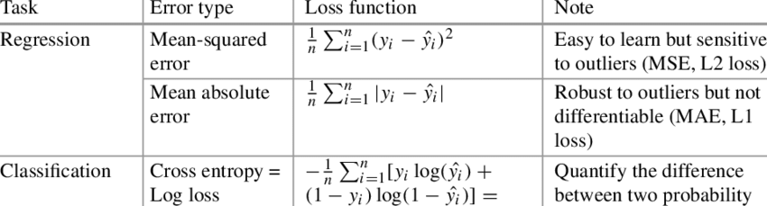

#### As you can see in the picture Cross-entropy is prefered for Classification ,but MSE is for regression.Actually , in classification we will work with very particular set of possible output values so MSE is badly defined,

```python
model = keras.Sequential()
model.add(keras.layers.Input(shape=(28,28,1)))
model.add(keras.layers.Flatten())
model.add(keras.layers.Dense(1024))
model.add(keras.layers.LeakyReLU(alpha=0.05))
model.add(keras.layers.Dense(512))
model.add(keras.layers.LeakyReLU(alpha=0.05))
model.add(keras.layers.Dense(26, activation='softmax'))
model.compile(optimizer='adam', loss="mean_squared_error",metrics=['accuracy'])
model.summary()
```

```
Model: "sequential_10"
_________________________________________________________________
 Layer (type)                Output Shape              Param #
=================================================================
 flatten_13 (Flatten)        (None, 784)               0

 dense_39 (Dense)            (None, 1024)              803840

 leaky_re_lu_20 (LeakyReLU)  (None, 1024)              0

 dense_40 (Dense)            (None, 512)               524800

 leaky_re_lu_21 (LeakyReLU)  (None, 512)               0

 dense_41 (Dense)            (None, 26)                13338

=================================================================
Total params: 1,341,978
Trainable params: 1,341,978
Non-trainable params: 0
_________________________________________________________________
```

```python
log = model.fit(X_train,Y_train,batch_size=32, epochs=10,validation_data=(X_test,Y_test))
```

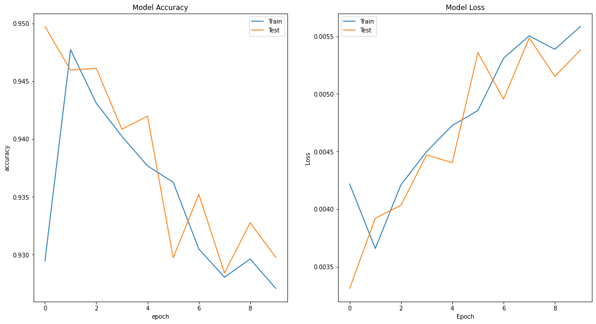

```python
plt.figure(figsize=(17,9))
plt.subplot(1,2,1)
plt.plot(log.history['accuracy'])
plt.plot(log.history['val_accuracy'])
plt.title('Model Accuracy')
plt.ylabel('accuracy')
plt.xlabel('epoch')
plt.legend(['Train', 'Test'])
plt.subplot(1,2,2)
plt.plot(log.history['loss'])
plt.plot(log.history['val_loss'])
plt.title('Model Loss')
plt.ylabel('Loss')
plt.xlabel('Epoch')
plt.legend(['Train', 'Test'])
plt.show()
```

```python
Y_pred = model.predict(X_test, batch_size=32, verbose=1)
Y_pred_bool = np.argmax(np.array(Y_pred), axis=1)

print(classification_report(Y_pred_bool,np.argmax(np.array(Y_test), axis=1)))
```

```
              precision    recall  f1-score   support

           0       0.93      0.93      0.93      2108
           1       0.82      0.94      0.88      1156
           2       0.98      0.86      0.91      4043
           3       0.77      0.91      0.83      1287
           4       0.80      0.95      0.87      1419
           5       0.72      0.95      0.82       130
           6       0.88      0.90      0.89       867
           7       0.78      0.94      0.85       898
           8       0.87      0.91      0.89       183
           9       0.88      0.87      0.88      1300
          10       0.76      0.94      0.84       707
          11       0.94      0.90      0.92      1741
          12       0.95      0.94      0.95      1799
```

[output cut: 17 more lines]

# Regularization:

```python
model = keras.Sequential()
model.add(keras.layers.Input(shape=(28,28,1)))
model.add(keras.layers.Flatten())
model.add(keras.layers.Dense(1024,kernel_regularizer=keras.regularizers.l2(l2=0.0001)))
model.add(keras.layers.LeakyReLU(alpha=0.05))
model.add(keras.layers.Dense(512,kernel_regularizer=keras.regularizers.l2(l2=0.0001)))
model.add(keras.layers.LeakyReLU(alpha=0.05))
model.add(keras.layers.Dense(26, activation='softmax',kernel_regularizer=keras.regularizers.l2(l2=0.0001)))
model.compile(optimizer='adam', loss="binary_crossentropy",metrics=['accuracy'])
model.summary()
```

```
Model: "sequential_13"
_________________________________________________________________
 Layer (type)                Output Shape              Param #
=================================================================
 flatten_16 (Flatten)        (None, 784)               0

 dense_42 (Dense)            (None, 1024)              803840

 leaky_re_lu_22 (LeakyReLU)  (None, 1024)              0

 dense_43 (Dense)            (None, 512)               524800

 leaky_re_lu_23 (LeakyReLU)  (None, 512)               0

 dense_44 (Dense)            (None, 26)                13338

=================================================================
Total params: 1,341,978
Trainable params: 1,341,978
Non-trainable params: 0
_________________________________________________________________
```

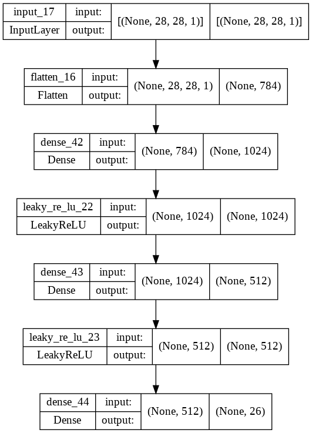

```python
keras.utils.plot_model(model, show_shapes=True, expand_nested=True)
```

```python
log = model.fit(X_train,Y_train,batch_size=32, epochs=10,validation_data=(X_test,Y_test))
```

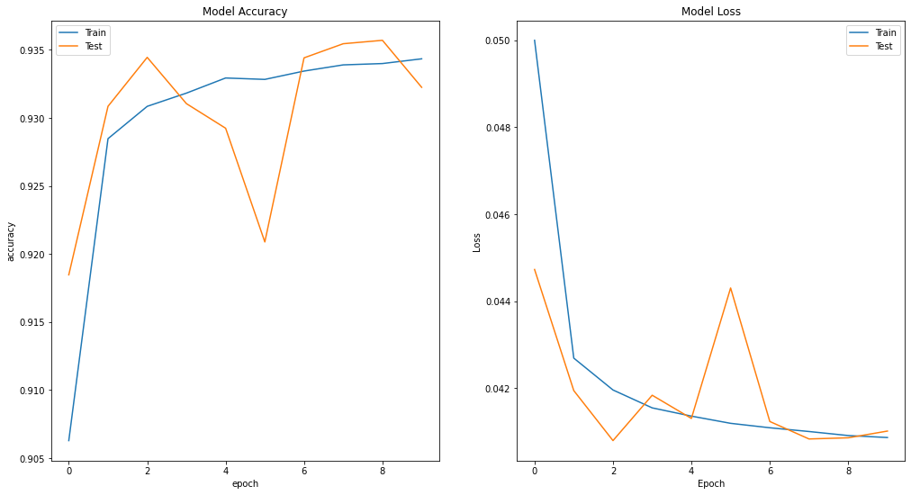

```python
plt.figure(figsize=(17,9))
plt.subplot(1,2,1)
plt.plot(log.history['accuracy'])
plt.plot(log.history['val_accuracy'])
plt.title('Model Accuracy')
plt.ylabel('accuracy')
plt.xlabel('epoch')
plt.legend(['Train', 'Test'])
plt.subplot(1,2,2)
plt.plot(log.history['loss'])
plt.plot(log.history['val_loss'])
plt.title('Model Loss')
plt.ylabel('Loss')
plt.xlabel('Epoch')
plt.legend(['Train', 'Test'])
plt.show()
```

```python
Y_pred = model.predict(X_test, batch_size=32, verbose=1)
Y_pred_bool = np.argmax(np.array(Y_pred), axis=1)

print(classification_report(Y_pred_bool,np.argmax(np.array(Y_test), axis=1)))
```

```
              precision    recall  f1-score   support

           0       0.94      0.91      0.92      2203
           1       0.89      0.92      0.90      1274
           2       0.95      0.95      0.95      3543
           3       0.74      0.95      0.83      1205
           4       0.86      0.95      0.91      1534
           5       0.77      0.96      0.85       139
           6       0.89      0.84      0.86       941
           7       0.82      0.89      0.85      1001
           8       0.50      1.00      0.66        95
           9       0.88      0.90      0.89      1261
          10       0.82      0.85      0.84       846
          11       0.98      0.87      0.92      1879
          12       0.94      0.93      0.93      1800
```

[output cut: 17 more lines]

# Dropout:

### It is a regularization technique for neural networks that drops a unit with its connections at training time with a specified probability. At test time, all units are present, but with weights scaled by specified probability.

```python
model = keras.Sequential()
model.add(keras.layers.Input(shape=(28,28,1)))
model.add(keras.layers.Flatten())
model.add(keras.layers.Dense(1024))
model.add(keras.layers.LeakyReLU(alpha=0.05))
model.add(keras.layers.Dropout(0.1))
model.add(keras.layers.Dense(512))
model.add(keras.layers.LeakyReLU(alpha=0.05))
model.add(keras.layers.Dropout(0.1))
model.add(keras.layers.Dense(26, activation='softmax'))
model.compile(optimizer='adam', loss="binary_crossentropy",metrics=['accuracy'])
model.summary()
```

```
Model: "sequential_15"
_________________________________________________________________
 Layer (type)                Output Shape              Param #
=================================================================
 flatten_18 (Flatten)        (None, 784)               0

 dense_48 (Dense)            (None, 1024)              803840

 leaky_re_lu_26 (LeakyReLU)  (None, 1024)              0

 dropout_4 (Dropout)         (None, 1024)              0

 dense_49 (Dense)            (None, 512)               524800

 leaky_re_lu_27 (LeakyReLU)  (None, 512)               0

 dropout_5 (Dropout)         (None, 512)               0

 dense_50 (Dense)            (None, 26)                13338

=================================================================
Total params: 1,341,978
Trainable params: 1,341,978
Non-trainable params: 0
_________________________________________________________________
```

```python
log = model.fit(X_train,Y_train,batch_size=32, epochs=10,validation_data=(X_test,Y_test))
```

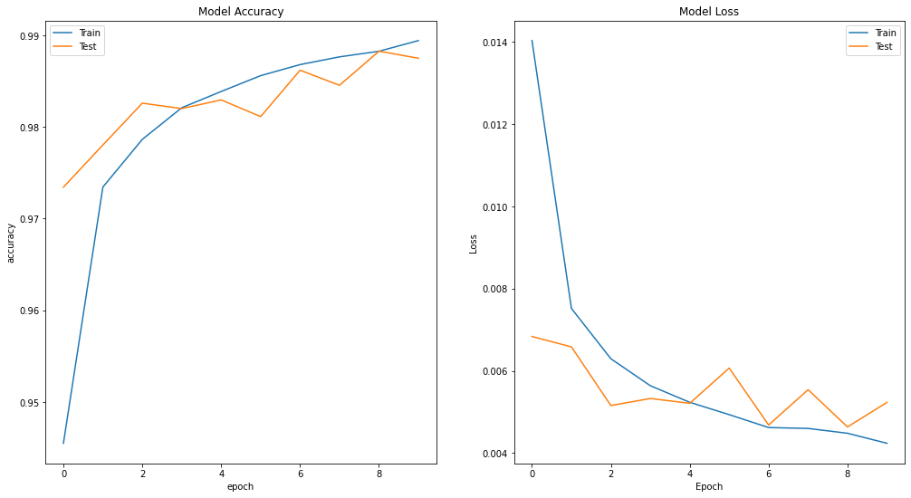

```python
plt.figure(figsize=(17,9))
plt.subplot(1,2,1)
plt.plot(log.history['accuracy'])
plt.plot(log.history['val_accuracy'])
plt.title('Model Accuracy')
plt.ylabel('accuracy')
plt.xlabel('epoch')
plt.legend(['Train', 'Test'])
plt.subplot(1,2,2)
plt.plot(log.history['loss'])
plt.plot(log.history['val_loss'])
plt.title('Model Loss')
plt.ylabel('Loss')
plt.xlabel('Epoch')
plt.legend(['Train', 'Test'])
plt.show()
```

```python
Y_pred = model.predict(X_test, batch_size=32, verbose=1)
Y_pred_bool = np.argmax(np.array(Y_pred), axis=1)

print(classification_report(Y_pred_bool,np.argmax(np.array(Y_test), axis=1)))
```

```
              precision    recall  f1-score   support

           0       0.99      0.98      0.99      2145
           1       0.97      0.99      0.98      1285
           2       0.99      0.99      0.99      3550
           3       0.94      0.98      0.96      1466
           4       0.99      0.99      0.99      1686
           5       0.94      0.99      0.97       164
           6       0.98      0.98      0.98       883
           7       0.98      0.97      0.97      1096
           8       0.97      0.99      0.98       186
           9       0.96      0.99      0.97      1239
          10       0.98      0.97      0.98       878
          11       0.97      1.00      0.98      1626
          12       0.99      0.99      0.99      1769
```

[output cut: 17 more lines]